# R Notebook

我们观察34回合前后7局，前7局1 1 1 0 1 0 1,后7局0 0 0 1 0 0 0,表明中国队由优势局面转变为了落后局面

观察42回合前后10局，前10局 0 1 0 0 0 0 1 0 0 0,中国队落后很多，后10局 1 0 1 1 1 0 0 1 0 1,中国队奋起直追，追回了一些劣势

发现第四局中国队是先优势再劣势又优势的局面，挽回了中局时一度的败局，最终取得了第四局的胜利

接下来分析第五局

```
## [1] "radius is : 5 the round of pvalue<0.05 : "
```

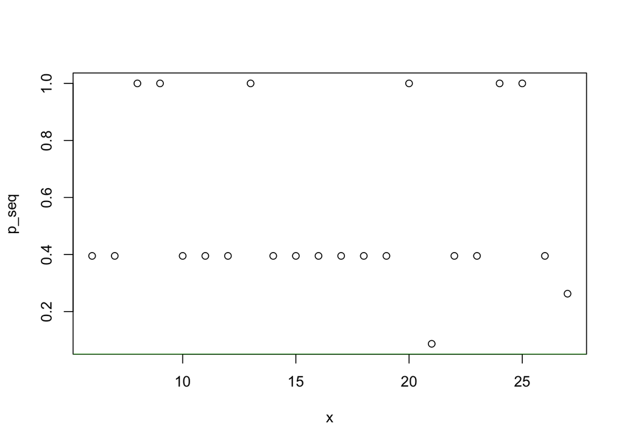

```
## [1] "radius is : 6 the round of pvalue<0.05 : "
```

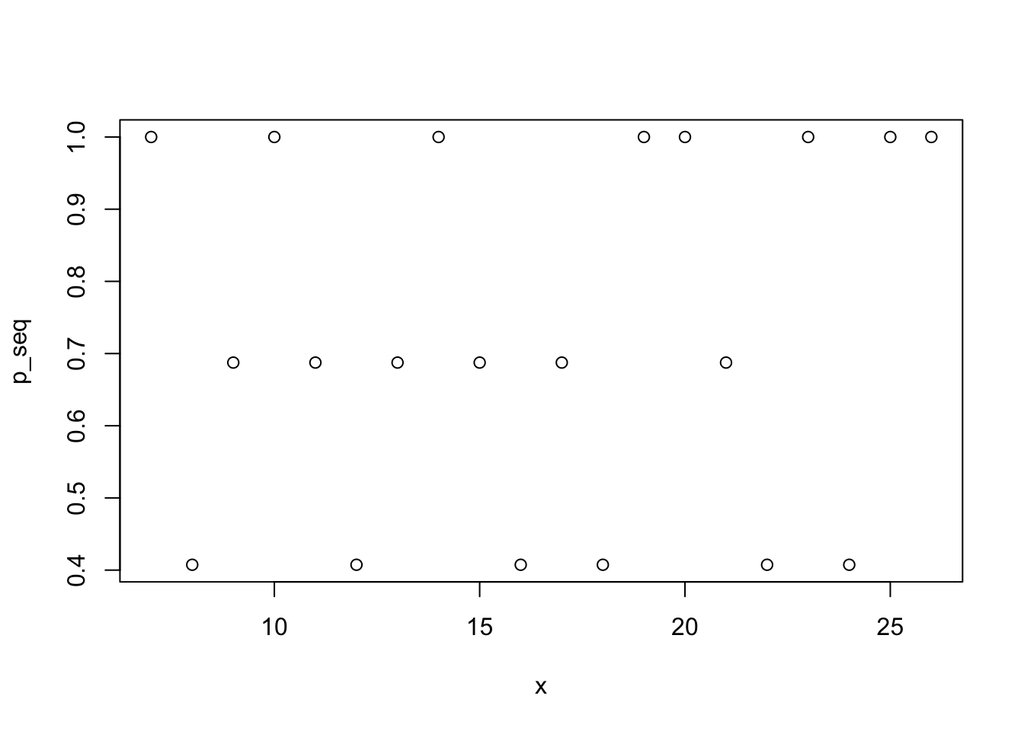

```
## [1] "radius is : 7 the round of pvalue<0.05 : "
```

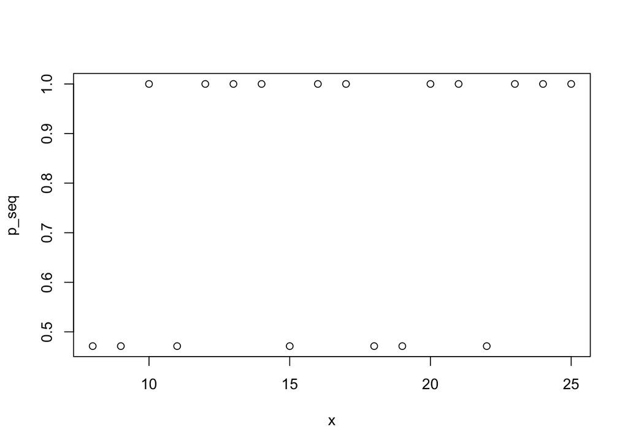

```
## [1] "radius is : 8 the round of pvalue<0.05 : "
```

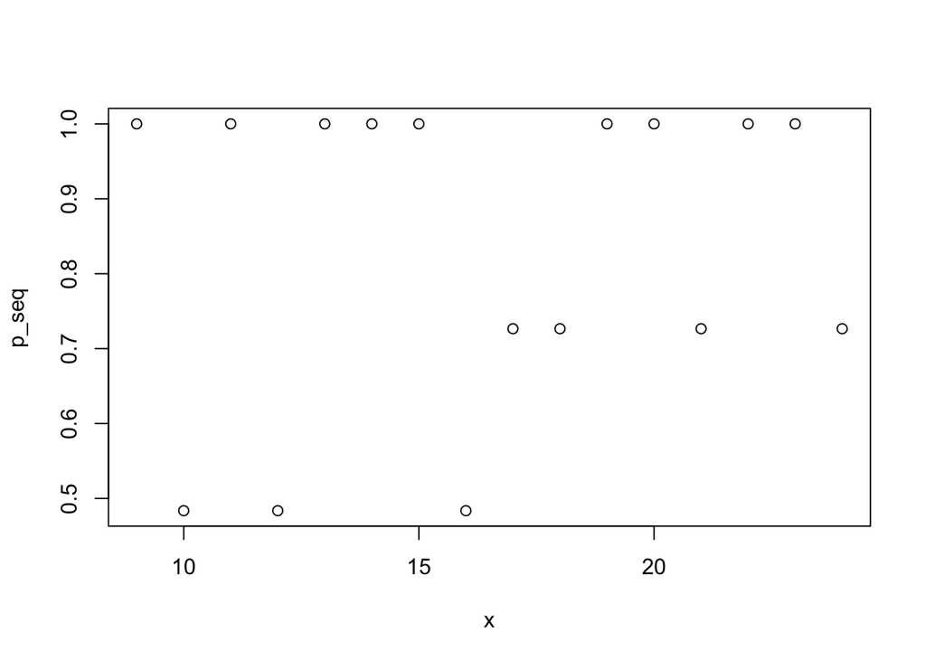

```
## [1] "radius is : 9 the round of pvalue<0.05 : "
```

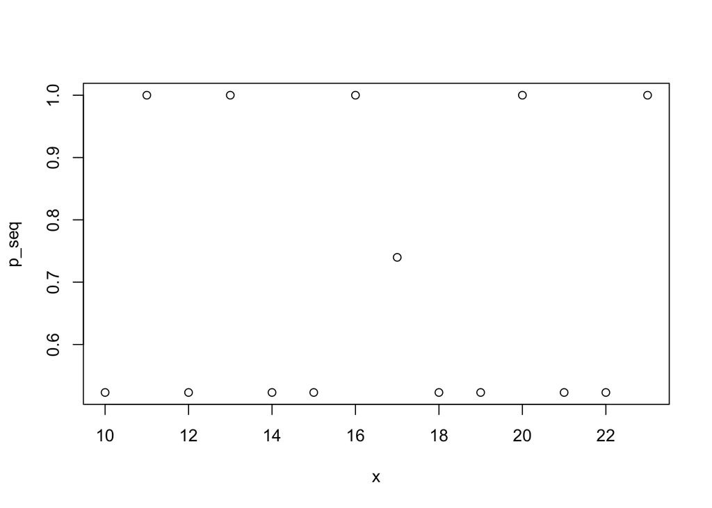

```
## [1] "radius is : 10 the round of pvalue<0.05 : "
```

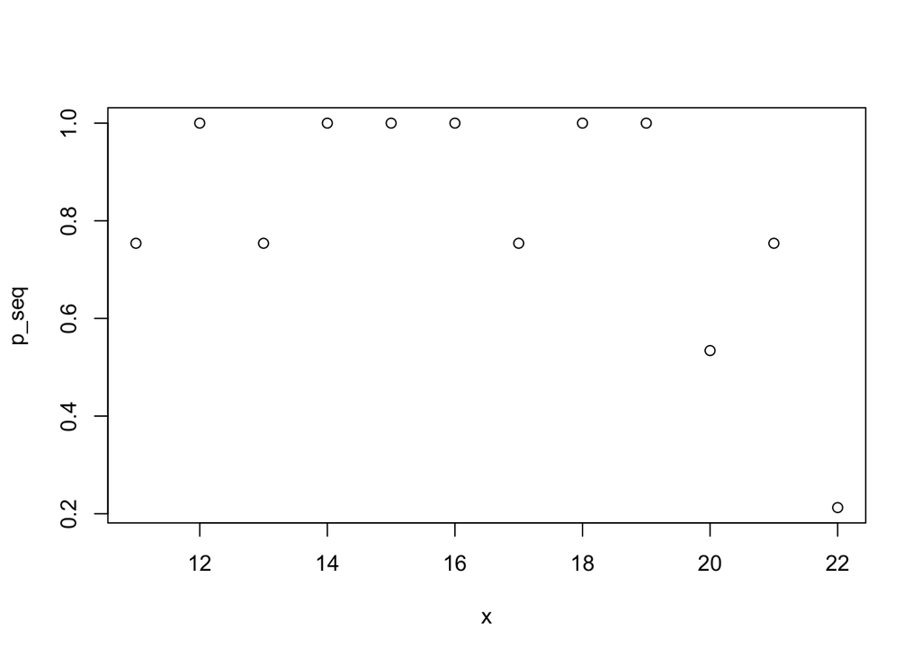

```r
for(r in 5:10){
  res<-sym_sign_test(r,g5)
  print(paste0("radius is : ",r," the round of pvalue<0.05 : ",(which(res<0.05)+r)))
  pval_plot(res, r)
}
```

发现我们无法找出在0.05显著性水平下的局点，第五局作为决胜局，双方僵持不下，更是达到了第32回合才决出胜负，但是中国对欠缺了一些运势，输掉了整场比赛。

纵观整场比赛，从得分序列对称比较的符号检验分析来看，中国队主要失败的原因是不能有效的将“优势”转变为“胜势”，也很难力挽狂澜，将败局逆转。输掉的比赛均是因为劣势期的连续失分太多，在优势期已经没有时间扳回。